# Préparation CCF E5.2 : Régie d’éclairage

Ce système sera utilisé dans le cadre de l’épreuve de CCF E5.2.

## Présentation

La régie d’éclairage est un système permettant de commander un ensemble d’appareils (lyres, scanners, lasers etc.) compatibles avec le bus DMX512, bus standard du spectacle. Il peut être utilisé dans le cadre d’une scène de spectacle, des salles de musée, …

[figure not shown]

Le système est constitué :

- d’appareils d’éclairage (scanners, gradateurs, projecteurs lyres, projecteurs led, …) compatibles avec le bus standard du spectacle (DMX 512) ;
- d’une console professionnelle réseau (« Ethernet UDP/IP ») de type Enttec PlayBack Wing permettant de piloter les appareils DMX à distance ;
- d’une interface de communication DMX/USB (modèle “OPEN DMX USB” ou “DMX USB PRO” de la société Enttec) ;
- d’un réseau cablé Ethernet 100BASET ;
- d’un switch Ethernet ;
- d’un poste de supervision et de commande ;
- manuels, logiciels de tests et supervision.

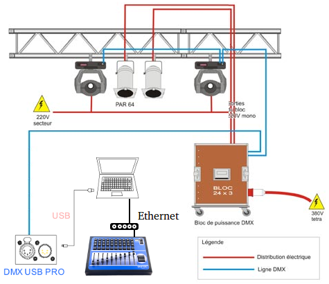

Le régisseur dispose d’un ordinateur de type PC et d’un ensemble de projecteurs respectant la norme DMX512 :

- Projecteur LED 56 (PAR Led 56) : ce projecteur fonctionne à base de LED qui sont divisées en trois canaux : Le rouge, vert et bleu. Le nombre de canaux change en fonction du projecteur utilisé. Principalement, on note l’existence obligatoire de 3 canaux correspondants aux couleurs primaires puis des canaux supplémentaires comme le « Dimmer » et/ou le « Strobe ».
- Projecteur Lyre : ce type de projecteur possède des canaux de « PAN », « TILT », « GLOBOS » et « Couleur » principalement. D’autres canaux peuvent éventuellement se rajouter en fonction de l’appareil utilisé.
- Projecteur scanner : ce type de projecteur utilise une série de LED pour afficher différents motifs. Il possède principalement 3 canaux comme le « PAN », le « TILT » ou encore la « Couleur ». Bien entendu, d’autre canaux peuvent se rajouter en plus.

[figure not shown]

Pour communiquer avec l’ensemble des appareils DMX512, on utilisera une interface de communication fabriquée par la société Enttec qui sera reliée en USB à l’ordinateur (modèle “OPEN DMX USB” ou “DMX USB PRO”).

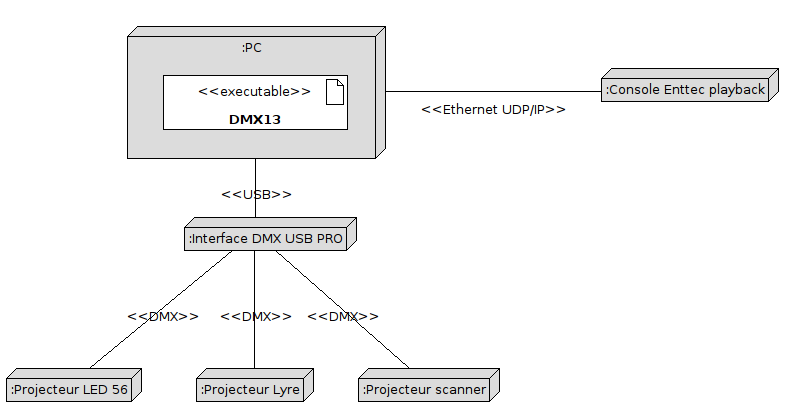

Le diagramme des cas d’utilisation est le suivant :

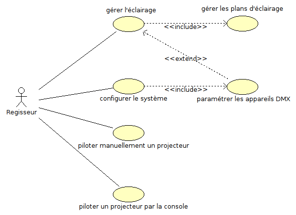

## Contraintes d’environnement

| Ressource | Version |
| --- | --- |
| OS | GNU Linux (Ubuntu 12.04.5 LTS) |
| EDI | Qt Creator 2.4.1 |
| Compilateur | GNU g++/gcc version 4.6.3 |
| Débugueur | GNU gdb 7.4 |
| Fabrication | QMake 2.01a et GNU make 3.81 |
| API GUI | Qt 4.8.1 |

## Manuel d’installation

Exécuter le programme setup :

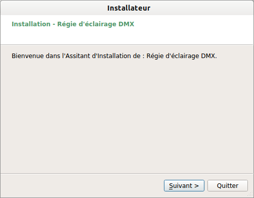

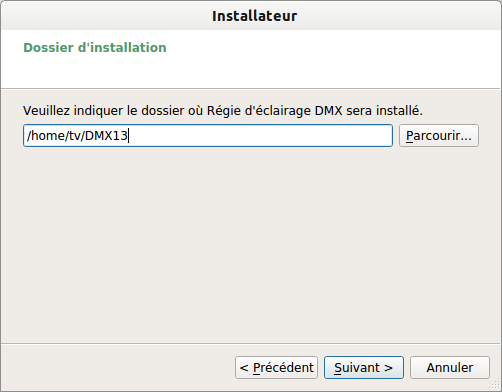

Vous pouvez installer les deux logiciels avec leurs fichiers de configuration XML :

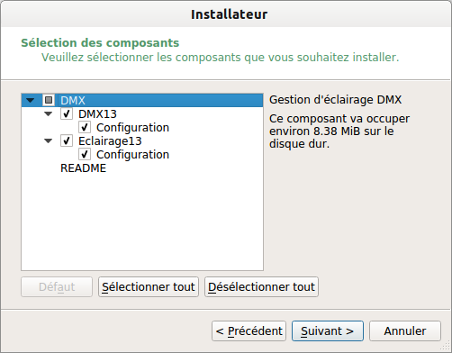

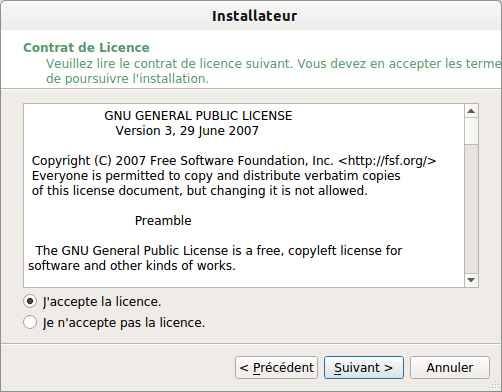

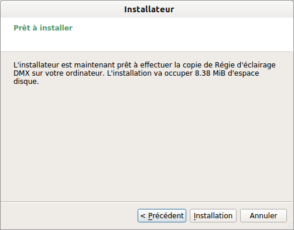

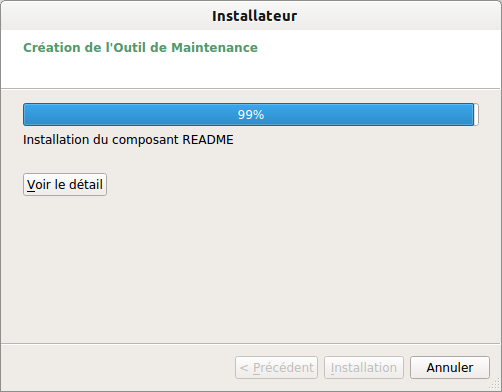

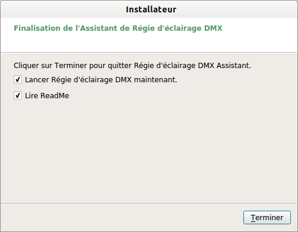

L’application gère ses paramètres de configuration et ses données à partir de fichiers XML :

- `adaptateur.xml` qui contient la liste des adaptateurs DMX-USB gérés
- `appareils.xml` qui décrit les appareils DMX (nom, canaux et type) contrôlés
- `scenarios.xml` qui fournit l’ensemble des scénarios pour un spectacle
- `scenes.xml` qui décrit les plans d’éclairage (ensemble de réglages pour les appareils connectés)
- `sequences.xml` qui fournit l’enchaînement des scènes séparées par des temporisations réglables

Exemple de fichier `adaptateur.xml` :

```xml
<?xml version="1.0" encoding="UTF-8"?>
<DMX13>
  <adaptateur id="1">
    <adresse>/dev/ttyUSB0</adresse>
    <UUID>{bffc06ec-ba69-424a-976b-8a771cb319ad}</UUID>
  </adaptateur>
</DMX13>
```

Exemple de fichier `appareils.xml` :

```xml
<?xml version='1.0' encoding='UTF-8'?>
<DMX13>
  <peripherique nom="Par LED 1" nbCanal="4" type="PAR LED" uuid="{f163b05a-58bf-46d9-887b-a4e9a0ad8f11}">
    <canal id="1">RED</canal>
    <canal id="2">GREEN</canal>
    <canal id="3">BLUE</canal>
    <canal id="4">DIMSTRO</canal>
  </peripherique>
  <peripherique nom="Scanner Numéro 1" nbCanal="3" type="SCANNER" uuid="{83fe644d-acbb-4b31-a9ee-06882b204556}">
    <canal id="32">PAN</canal>
    <canal id="33">TILT</canal>
    <canal id="34">GLOBOS</canal>
  </peripherique>
  <peripherique nom="Lyre au sol" nbCanal="5" type="LYRE" uuid="{16dc3967-5ea3-42a4-a29d-b16131eb62c4}">
    <canal id="132">PAN</canal>
    <canal id="133">TILT</canal>
    <canal id="129">GLOBOS</canal>
    <canal id="131">COULEUR</canal>
    <canal id="128">STROBE</canal>
  </peripherique>
  <peripherique nom="Par LED 2" nbCanal="3" type="PAR LED" uuid="{be786ddb-9af0-4b94-bf2c-7b175b9e56d6}">
    <canal id="10">RED</canal>
    <canal id="11">GREEN</canal>
    <canal id="12">BLUE</canal>
  </peripherique>
</DMX13>
```

Exemple de fichier `scenarios.xml` :

```xml
<?xml version='1.0' encoding='UTF-8'?>
<DMX13>
  <scenario nom="salle 1" uuid="{cd623144-2ef5-4767-a824-39487693f6e4}"/>
</DMX13>
```

Exemple de fichier `scenes.xml` :

```xml
<?xml version='1.0' encoding='UTF-8'?>
<DMX13>
  <scene scenarioUUID="{cd623144-2ef5-4767-a824-39487693f6e4}" nom="scene1" uuid="{c22837d7-b0d7-4c48-9e87-3efe40dd147e}">
    <canal valeur="30" id="1"/>
    <canal valeur="0" id="2"/>
    <canal valeur="0" id="3"/>
    <canal valeur="0" id="4"/>
    <canal valeur="0" id="10"/>
    <canal valeur="0" id="11"/>
    <canal valeur="0" id="12"/>
    <canal valeur="0" id="132"/>
    <canal valeur="0" id="133"/>
    <canal valeur="0" id="129"/>
    <canal valeur="0" id="131"/>
    <canal valeur="0" id="128"/>
    <canal valeur="0" id="32"/>
    <canal valeur="0" id="33"/>
    <canal valeur="0" id="34"/>
  </scene>
  <scene scenarioUUID="{cd623144-2ef5-4767-a824-39487693f6e4}" nom="scene2" uuid="{36810501-4ded-42e9-8e5b-e4748ec0f760}">
    <canal valeur="0" id="1"/>
    <canal valeur="0" id="2"/>
    <canal valeur="0" id="3"/>
    <canal valeur="0" id="4"/>
    <canal valeur="0" id="10"/>
    <canal valeur="0" id="11"/>
    <canal valeur="0" id="12"/>
    <canal valeur="0" id="132"/>
    <canal valeur="0" id="133"/>
    <canal valeur="0" id="129"/>
    <canal valeur="0" id="131"/>
    <canal valeur="0" id="128"/>
    <canal valeur="0" id="32"/>
    <canal valeur="0" id="33"/>
    <canal valeur="0" id="34"/>
  </scene>
</DMX13>
```

Exemple de fichier `scequences.xml` :

```xml
<?xml version='1.0' encoding='UTF-8'?>
<DMX13>
  <sequence nom="hollywood" uuid="{4f73cde8-3dd0-4e8f-98bc-4ca179efc3ad}">
    <scene uuidScene="{c22837d7-b0d7-4c48-9e87-3efe40dd147e}" temporisation="5" uuid="{2e3fd287-9a1d-49d6-a369-4a26f8d0bac8}"/>
    <scene uuidScene="{36810501-4ded-42e9-8e5b-e4748ec0f760}" temporisation="5" uuid="{c393dd35-7f86-4c46-8ce0-7c92c7d0e451}"/>
  </sequence>
</DMX13>
```

## Manuel d’utilisation

Le système est contrôlé par deux logiciels distincts :

- **DMX13** : ce logiciel permet la configuration du spectacle ou l’animation à gérer.

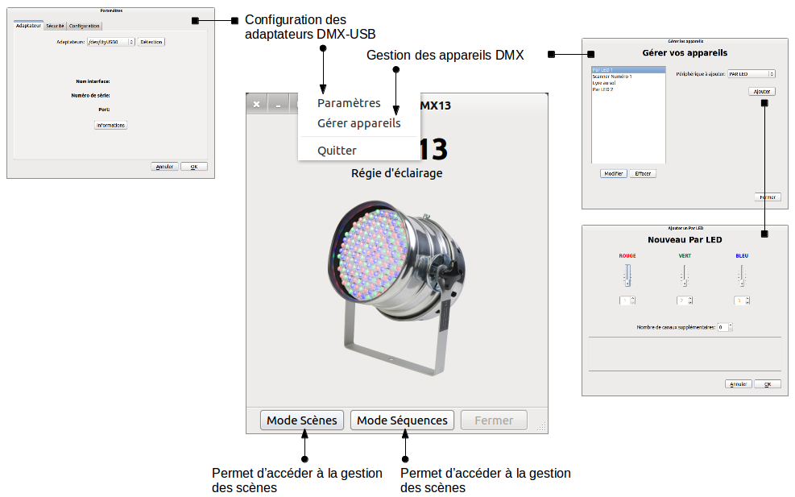

Le mode `Scènes` permet de définir les plans d’éclairage et de les tester en réel :

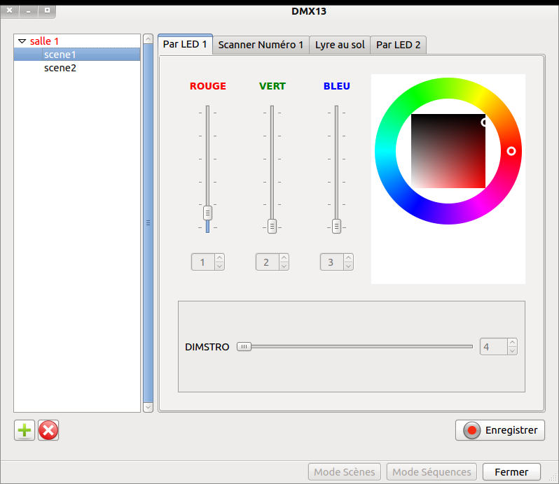

Le mode `Séquences` permet de créer et jouer les enchaînements de scènes séparées par des temporisations réglables :

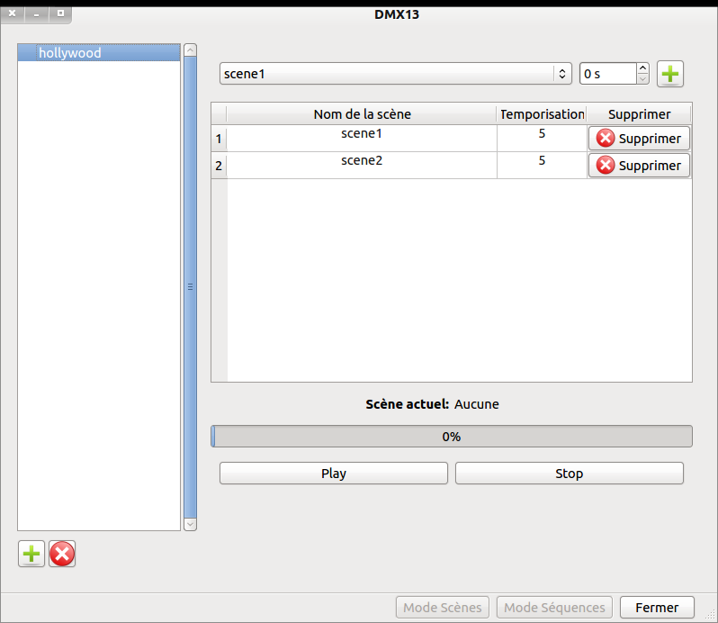

- **Eclairage13** : ce logiciel exploite les séquences et plans d’éclairage crées par DMX13 afin de les jouer de manière automatique :

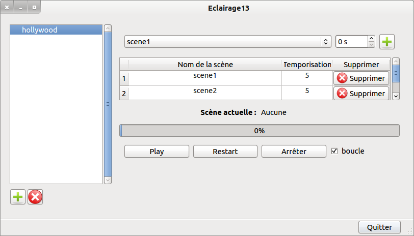

```
Les applications consignent des messages, évènements, avertissements et erreurs dans un journal de log.
```

## Glossaire

- DMX512 (*Digital Multiplexing* à 512 canaux) : protocole de multiplexage de données utilisé pour l’éclairage dynamique et la sonorisation de spectacle. Le protocole DMX512 utilise généralement une liaison série respectant la norme RS485 à 250 kbits/s et permet de contrôler 512 canaux (9 bits d’adressage) en affectant à chacun une valeur comprise entre 0 et 255 (8 bits de données par canal). La trame DMX (envoyé 44 fois par seconde) contient les 512 canaux, et chaque appareil reçoit donc en même temps l’ensemble des 512 valeurs. Lien : [www.usitt.org](http://www.usitt.org/Resources/Standards2/DMX512).
- Connecteur XLR : type de connecteur utilisé pour le raccordement des câbles (constitués d’une paire blindée d’une impédance de 120 ohms) DMX. On distingue le connecteur XLR de type 5 broches (standard de la norme) dont les broches 4 et 5 ne sont pas connectées et le type 3 broches.
- Canal : chaque appareil branché sur le bus DMX possède des canaux qui correspondent à des fonctions (gobos, dimmer, …) de ce dispositif. Les numéros des canaux sont configurables pour chaque appareil.
- Adresse : numéro du canal occupé sur le bus DMX correspondant au premier canal d’un appareil.
- Dimmer : réglage de la luminosité (mécanique ou électronique).
- Gobos : forme (géométriques, dessin, logos…) interposée dans le faisceau.
- Pan : réglage de la position du projecteur dans le plan vertical.
- Tilt : réglage de la position du projecteur dans le plan horizontal.
- Scène : ensemble des réglages pour tous les appareils connectés sur le bus DMX512 à un instant t.
- Séquence : suite de scènes séparées par des temporisations réglables.
- Scénario : ensemble de séquences.

## Activités

- Matériels : Console Enttec playback, Appareils DMX
- Interfaces de communication : DMX USB PRO, Ethernet
- Bus de terrain : DMX
- Réseau : UDP/IP
- Fichiers : LOG, XML

Retour au sommaire